# Fermentation Equivalency Excercise

## Overview

- 3 strains, A, B and C, were run at Delta and Zymergen. At Delta, 6 replicates were run for each strain; at Zymergen, 9, 8 and 6 replicates were run for strain A, B and C, respectively.

```r
data <- read_csv("~/Downloads/Delta_Zymergen Equivalency Data Scrubbed_20180605.csv")
data.df <- data.frame(Culture = data$Culture,
                      ExperimentID = data$`Experiment ID`,
                      TankID = data$`Tank ID`,
                      Site = data$Site,
                      Is_Zymergen = ifelse(data$Site=="Zymergen", "Yes", "No"),
                      Productivity = data$`Productivity [g/L/hr]`,
                      Yield = data$`Yield [%]`,
                      stringsAsFactors = default.stringsAsFactors())

table(data.df$Culture, data.df$Site)
```

```
##
##            Delta Zymergen
##   Strain A     6        9
##   Strain B     6        8
##   Strain C     6        6
```

```r
DT::datatable(data.df)
```

|  | Culture | ExperimentID | TankID | Site | Is_Zymergen | Productivity | Yield |
| --- | --- | --- | --- | --- | --- | --- | --- |
| 1 | Strain C | Thr18-03F |  | Delta | No | 3.05 | 44.5 |
| 2 | Strain C | Thr18-03F |  | Delta | No | 3.17 | 45 |
| 3 | Strain C | Thr18-03F |  | Delta | No | 3.12 | 44.3 |
| 4 | Strain C | Thr17-45F |  | Delta | No | 3.12 | 45.7 |
| 5 | Strain C | Thr17-44F |  | Delta | No | 3.23 | 45.7 |
| 6 | Strain C | Thr17-40F |  | Delta | No | 3.28 | 48.2 |
| 7 | Strain B | Thr18-06F |  | Delta | No | 2.73 | 37.7 |
| 8 | Strain B | Thr18-06F |  | Delta | No | 2.71 | 37.3 |
| 9 | Strain B | Thr18-08F |  | Delta | No | 2.72 | 40.7 |
| 10 | Strain B | Thr18-08F |  | Delta | No | 2.77 | 40.6 |

[output cut: 31 more lines]

### Data visualization

#### Distribution of Yield and Productivity

The following plots may be duplicated.

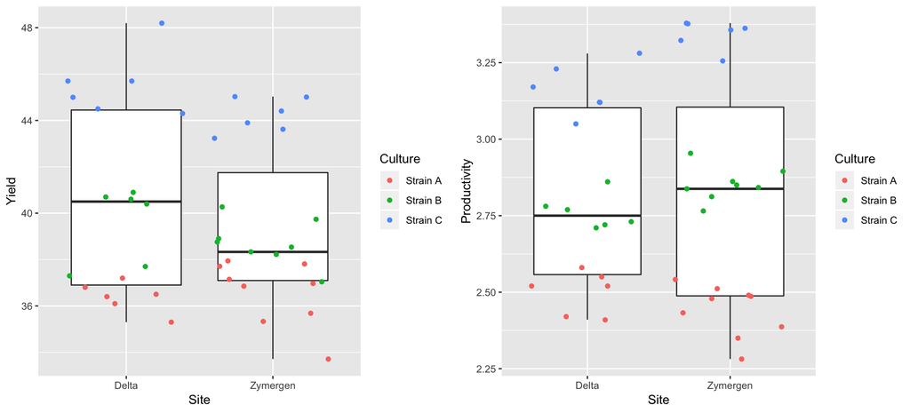

```r
p1 <- ggplot(data.df, aes(Site, Yield)) +
  geom_boxplot() +
  geom_jitter(aes(colour = Culture))

prod1 <- ggplot(data.df, aes(Site, Productivity)) +
  geom_boxplot() +
  geom_jitter(aes(colour = Culture))

grid.arrange(p1, prod1, nrow = 1)
```

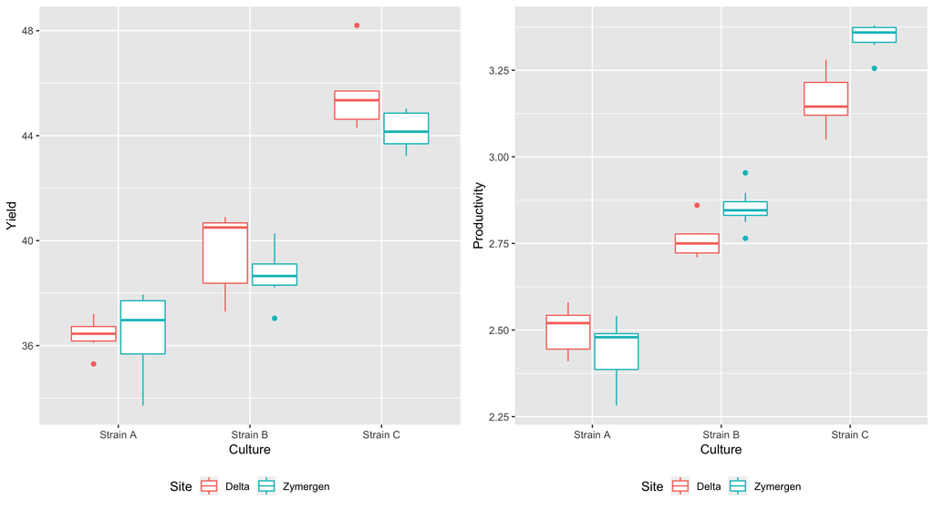

```r
p4 <- ggplot(data.df, aes(Culture, Yield, color=Site)) +
geom_boxplot() + theme(legend.position="bottom")

p5 <- ggplot(data.df, aes(Culture, Productivity, color=Site)) +
geom_boxplot() + theme(legend.position="bottom")

grid.arrange(p4, p5, nrow = 1)
```

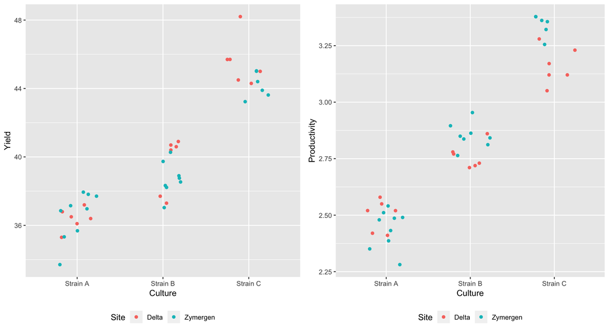

```r
p6 <- ggplot(data.df, aes(Culture, Yield, color=Site)) +
geom_jitter(width = 0.25) + theme(legend.position="bottom")

p7 <- ggplot(data.df, aes(Culture, Productivity, color=Site)) +
geom_jitter(width = 0.25) + theme(legend.position="bottom")

grid.arrange(p6, p7, nrow = 1)
```

#### Tank performance

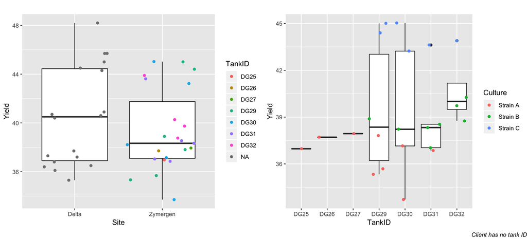

```r
p2 <- ggplot(data.df, aes(Site, Yield)) +
  geom_boxplot() +
  geom_jitter(aes(colour = TankID))

p3 <- ggplot(data.df %>% dplyr::filter(Site == "Zymergen"), aes(TankID, Yield)) +
  geom_boxplot() +
  geom_jitter(aes(colour = Culture))

grid.arrange(p2, p3, nrow = 1, top = "",
             bottom = textGrob(
    "Client has no tank ID",
    gp = gpar(fontface = 3, fontsize = 9),
    hjust = 1,
    x = 1
  )
)
```

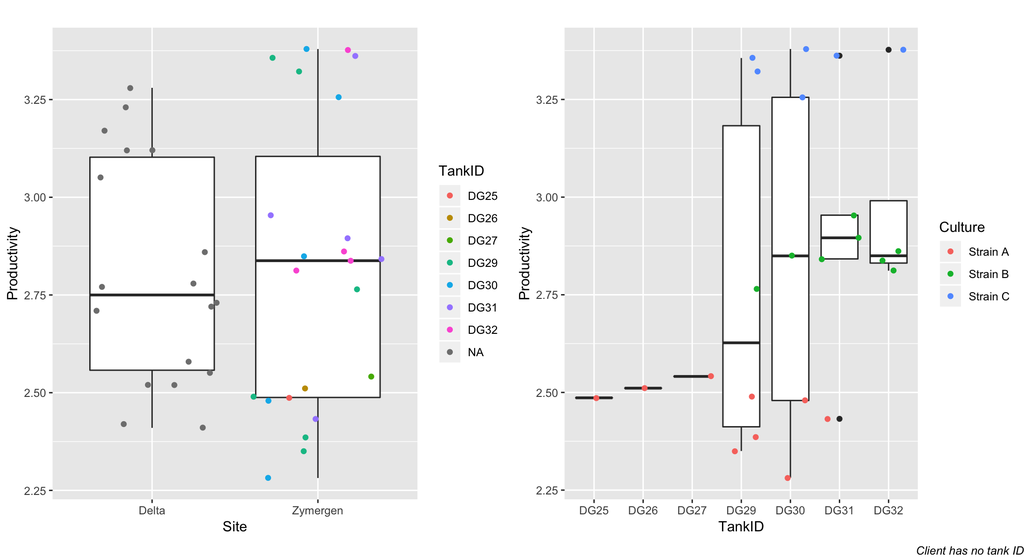

```r
prod2 <- ggplot(data.df, aes(Site, Productivity)) +
  geom_boxplot() +
  geom_jitter(aes(colour = TankID))

prod3 <- ggplot(data.df %>% dplyr::filter(Site == "Zymergen"),
                aes(TankID, Productivity)) +
  geom_boxplot() +
  geom_jitter(aes(colour = Culture))

grid.arrange(
  prod2,
  prod3,
  nrow = 1,
  top = "",
  bottom = textGrob(
    "Client has no tank ID",
    gp = gpar(fontface = 3, fontsize = 9),
    hjust = 1,
    x = 1
  )
)
```

## Equivalency Test

According to https://wiki.zymergen.net/display/DataScience/Fermentation+Equivalency, there are two model options to test whether Delta and Zymergen’s fermentation process is equivalent in Zymergen Data Science team.

### Option 1: Means Performance Model

We compute the threshold for the RMSE of the simple linear model fit between Zymergen and client data. For self containment and to specify that step the process would be:

```r
se_mat <- data.df %>% group_by(Culture) %>%
  dplyr::summarise(Yield_se = sd(Yield), Prod_se = sd(Productivity))

DT::datatable(se_mat, rownames = FALSE) %>%
  formatRound(c('Yield_se', 'Prod_se'), 4)
```

| Culture | Yield_se | Prod_se |
| --- | --- | --- |
| Strain A | 1.13510478658395 | 0.0822602457324565 |
| Strain B | 1.32428790734434 | 0.0709716349575992 |
| Strain C | 1.29333520610644 | 0.114164396307537 |

```r
2*mean(se_mat$Yield_se)
```

```
## [1] 2.501819
```

```r
2*mean(se_mat$Prod_se)
```

```
## [1] 0.1782642
```

```r
# Compute the average variability, and use that to compute (2*(Avg Variability)) / sqrt(N)
# var_mat <- data.df %>% group_by(Culture) %>%
#  dplyr::summarise(Yield_var = var(Yield), Prod_var = var(Productivity))

# DT::datatable(var_mat, rownames = FALSE)
# 2*mean(var_mat$Yield_var)/sqrt(3)

# 2*mean(var_mat$Prod_var)/sqrt(3)
```

3. Compute the average titers of interest for each strain at each site, then fit a simple linear regression using Zymergen as independent variable and Delta as the dependent variable.

```r
mat = data.df %>%
  group_by(Culture, Site) %>%
  dplyr::summarise(Yield_avg = mean(Yield), Prod_avg = mean(Productivity))

z_mat <- mat %>% dplyr::filter(Site == "Zymergen") %>% dplyr::arrange(Culture)
d_mat <- mat %>% dplyr::filter(Site == "Delta") %>% dplyr::arrange(Culture)
DT::datatable(z_mat, rownames = FALSE)
```

| Culture | Site | Yield_avg | Prod_avg |
| --- | --- | --- | --- |
| Strain A | Zymergen | 36.5729443771111 | 2.43971750016667 |
| Strain B | Zymergen | 38.725 | 2.852134700675 |
| Strain C | Zymergen | 44.1989134683333 | 3.3420143315 |

```r
DT::datatable(d_mat, rownames = FALSE)
```

| Culture | Site | Yield_avg | Prod_avg |
| --- | --- | --- | --- |
| Strain A | Delta | 36.3833333333333 | 2.5 |
| Strain B | Delta | 39.6 | 2.76166666666667 |
| Strain C | Delta | 45.5666666666667 | 3.16166666666667 |

```r
fit_yield <- lm(d_mat$Yield_avg ~ z_mat$Yield_avg)
fit_prod <- lm(d_mat$Prod_avg ~ z_mat$Prod_avg)

rmse <- function(fit) sqrt(mean(summary(fit)$residuals^2))
rmse(fit_prod)
```

```
## [1] 0.01919302
```

```r
rmse(fit_yield)
```

```
## [1] 0.2857858
```

If the RMSE of the fit is less than the threshold defined in step 2, then the process is assumed to be equivalent for both yield and productivity.

```r
paste0("If ", rmse(fit_yield), " < ", 2*mean(se_mat$Yield_se), ", yield is equivalant!")
```

```
## [1] "If 0.285785836634482 < 2.50181860002316, yield is equivalant!"
```

```r
paste0("If ", rmse(fit_prod), " < ", 2*mean(se_mat$Prod_se), ", productivity is equivalant!")
```

```
## [1] "If 0.0191930239302079 < 0.178264184665062, productivity is equivalant!"
```

### Option 2: Multilevel Model

This model attempts to fit a linear model like an least squares regression, but it allows for effects to vary between groups. Thus, I fit a mixed effects linear model

> Yield ~ Intercept + Is_Zymergen + (Is_Zymergen | Strain).

Which is interpreted as:

- The specific measurement value, Yield.
- A coefficient term for the global mean of the data, Intercept.
- A coefficient term for the site bias, Is_Zymergen.
- Multiple coefficient terms for the site bias that is allowed to vary by strain, (Is Zymergen | Strain).

```r
yield_model <- lmer(Yield ~ 1 + Is_Zymergen + (Is_Zymergen|Culture), data = data.df, REML = FALSE)
```

```
## singular fit
```

```r
### The fixed effects:
summary(yield_model)$coefficients
```

```
##                 Estimate Std. Error   t value
## (Intercept)    40.516667  2.2032656 18.389370
## Is_ZymergenYes -0.690806  0.5080057 -1.359839
```

```r
### The random effects:
ranef(yield_model)
```

```
## $Culture
##          (Intercept) Is_ZymergenYes
## Strain A   -3.969604      0.6364374
## Strain B   -1.098832      0.1761732
## Strain C    5.068436     -0.8126106
```

```r
### test whether site/Is_Zymergen effect is equal to zero
Anova(yield_model)
```

```
## Analysis of Deviance Table (Type II Wald chisquare tests)
##
## Response: Yield
##              Chisq Df Pr(>Chisq)
## Is_Zymergen 1.8492  1     0.1739
```

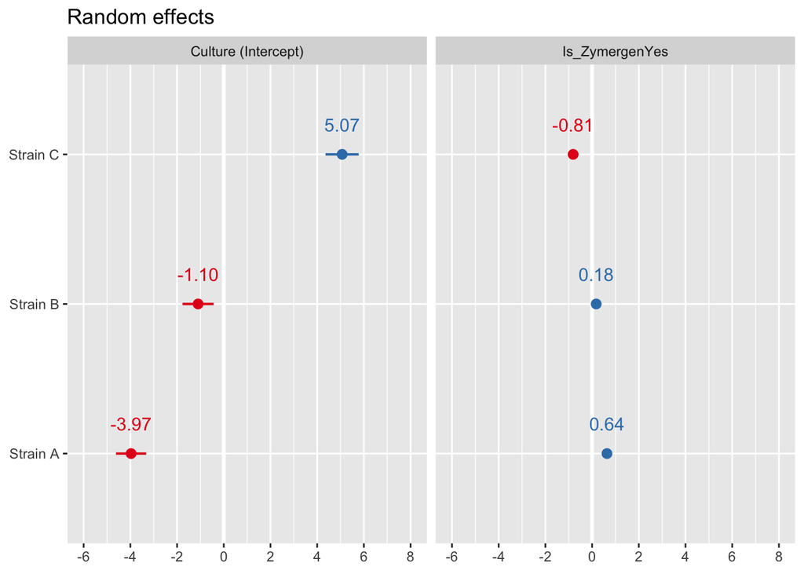

```r
### plot random effects
plot_model(yield_model, type = c("re"), show.values = TRUE, value.offset = .2)
```

```r
#plot_model(yield_model, type = "pred", vars=c('Is_Zymergen', 'Culture'), facet.grid = FALSE)
```

One can see the site effect is estimated -0.69 % yield, meaning that in the event of running the process at Zymergen one would expect the yield to be reduced by about 0.69%. This decrease is not statistically significant according to Anova test p-value 0.1739.

```r
prod_model <- lmer(Productivity ~ 1 + Is_Zymergen + (Is_Zymergen|Culture), data = data.df, REML = FALSE)
```

```
## singular fit
```

```r
### fixed effects
summary(prod_model)$coefficients
```

```
##                  Estimate Std. Error   t value
## (Intercept)    2.80777778 0.15744172 17.833759
## Is_ZymergenYes 0.07028066 0.06022526  1.166963
```

```r
### The random effects:
ranef(prod_model)
```

```
## $Culture
##          (Intercept) Is_ZymergenYes
## Strain A -0.31760025    -0.11435338
## Strain B -0.02678648    -0.00964459
## Strain C  0.34438673     0.12399797
```

```r
### test whether site/Is_Zymergen effect is equal to zero
Anova(prod_model)
```

```
## Analysis of Deviance Table (Type II Wald chisquare tests)
##
## Response: Productivity
##              Chisq Df Pr(>Chisq)
## Is_Zymergen 1.3618  1     0.2432
```

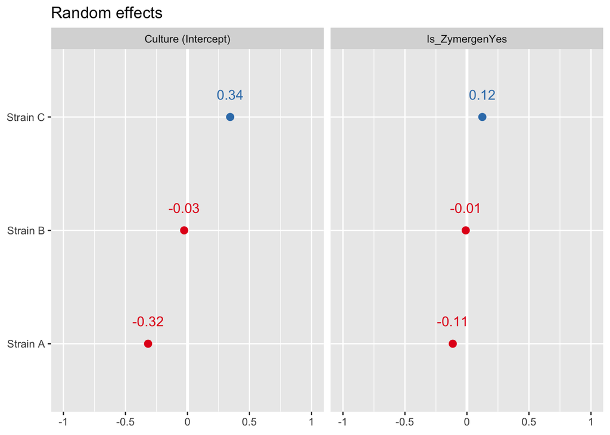

```r
### plot random effects
plot_model(prod_model, type = c("re"), show.values = TRUE, value.offset = .2)
```

One can see the site effect is estimated around 0.07, meaning that in the event of running the process at Zymergen one would expect the productivity to be improved by approximately 0.07 g/L/hr. This increase is not statistically significant according to Anova test p-value 0.2432.

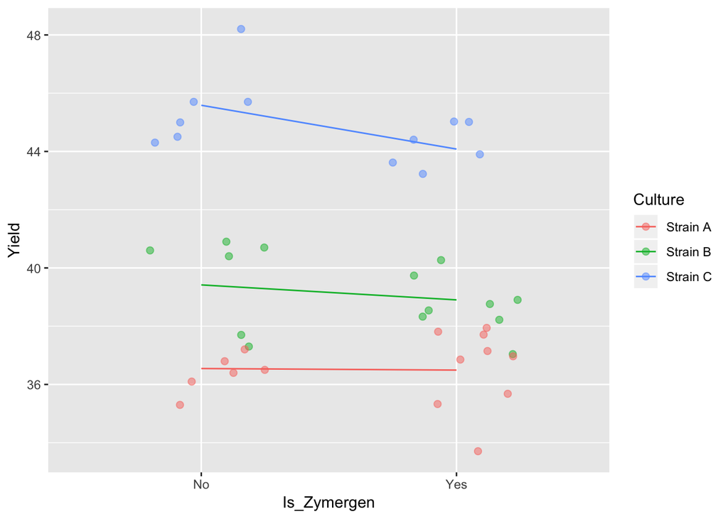

```r
ppyield <- ggplot(data.df, aes(x = Is_Zymergen, y = Yield, group = Culture, colour = Culture)) +
  geom_jitter(width = 0.25, size=2, alpha = 0.5) +
  geom_line(data = fortify(yield_model), aes(x = Is_Zymergen, y = .fitted, group = Culture, colour = Culture))
print(ppyield)
```

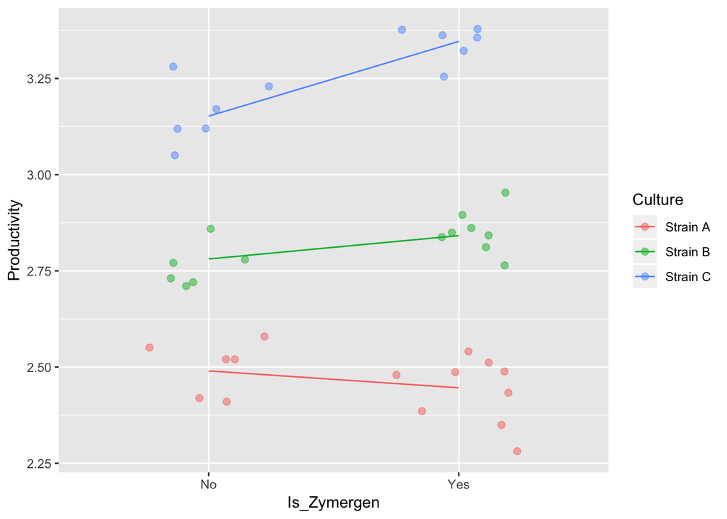

```r
ppprod <- ggplot(data.df, aes(x = Is_Zymergen, y = Productivity,
                              group = Culture, colour = Culture)) +
  geom_jitter(width = 0.25, size=2, alpha = 0.5) +
  geom_line(data = fortify(prod_model), aes(x = Is_Zymergen, y = .fitted,
                                            group = Culture, colour = Culture))
print(ppprod)
```